# Classification and Regression Trees (CART)

## The Curse of Dimensionality

Thus far we have described two types of machine learning algorithms: linear approaches (Logistic Regression and Naive Bayes), and a smoothing approach (k-Nearest Neighbors). A limitation of these approaches is that with a large number of predictors, we run into the problem of *the curse of dimensionality*.

The curse of dimensionality refers to various phenomena that arise when analyzing and organizing data in high-dimensional spaces that do not occur in low-dimensional settings such as the three-dimensional physical space of everyday experience.

The common theme of these problems is that when the dimensionality increases, the volume of the space increases so fast that the available data become sparse. In order to obtain a reliable result, the amount of data needed often grows exponentially with the dimensionality. Also, organizing and searching data often relies on detecting areas where objects form groups with similar properties; in high dimensional data, however, all objects appear to be sparse and dissimilar in many ways, which prevents common data organization strategies from being efficient.

Here we look at a set of elegant and versatile methods that adapt to higher dimensions and also allow these regions to take more complex shapes, but still produce models that are interpretable. These are very popular, well-known and studied methods. We will concentrate on Regression and Classification Trees and their extension to Random Forests.

## Decision Trees

Consider the olives dataset below. We show two measured predictors, `linoleic` (percent linoleic acid of sample) and `eicosenoic` (percent eicosenoic acid of sample). Suppose we wanted to predict the olive’s region using these two predictors.

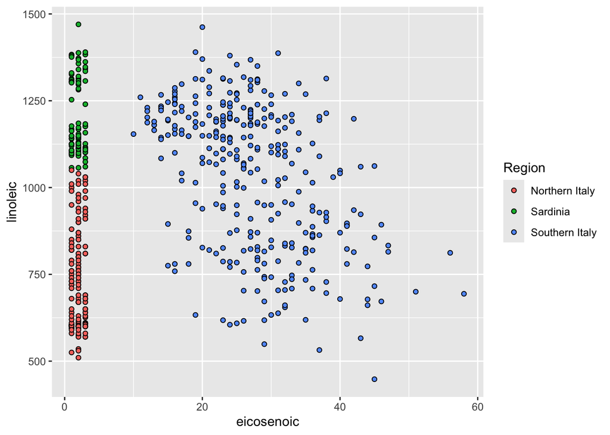

```r
olives <- read.csv("https://raw.githubusercontent.com/datasciencelabs/data/master/olive.csv", as.is = TRUE) %>% tbl_df
names(olives)[1] <- "province"
region_names <- c("Southern Italy", "Sardinia", "Northern Italy")
olives <- olives %>% mutate(Region = factor(region_names[Region]))

p <- olives %>% ggplot(aes(eicosenoic, linoleic, fill = Region)) +
     geom_point(pch = 21)
p
```

Note that we can describe a classification algorithm that would work pretty much perfectly:

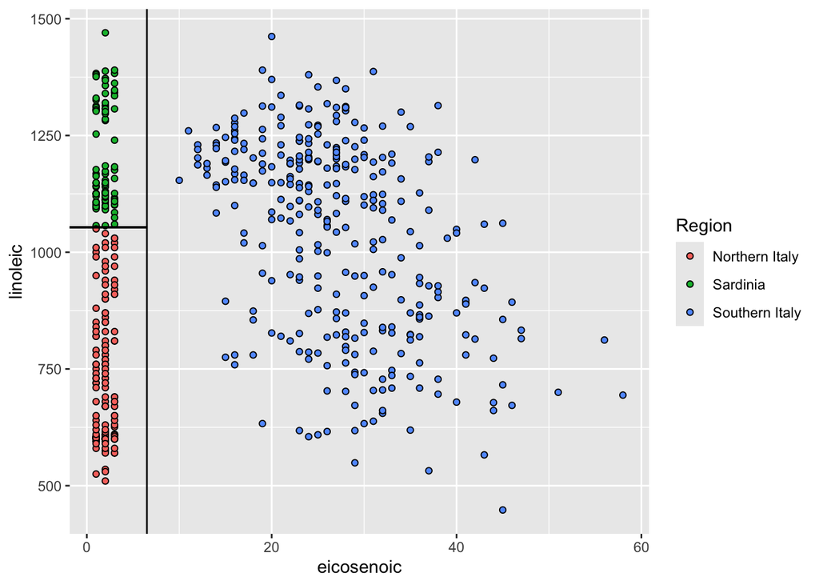

```r
p <- p + geom_vline(xintercept = 6.5) +
         geom_segment(x = -2, y = 1053.5, xend = 6.5, yend = 1053.5)
p
```

The prediction algorithm inferred from the figure above is what we call a decision tree. If eicosnoic is larger than 6.5, predict Southern Italy. If not, then if linoleic is larger than 1,054, predict Sardinia and Northern Italy otherwise. We can draw this decision tree like this:

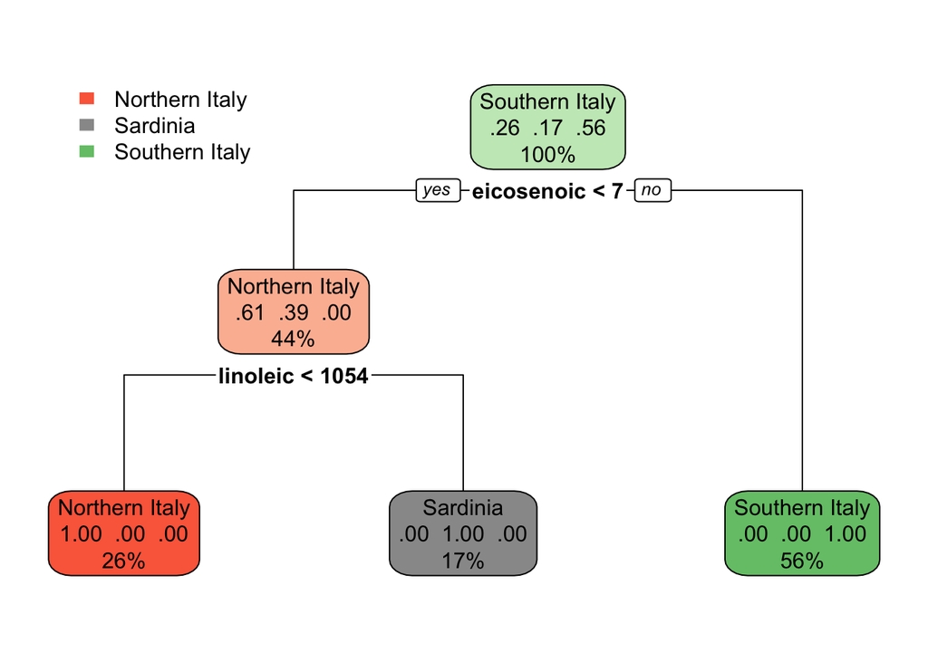

Decision trees like this are often used in practice. For example, to decide if a person is at risk of having a heart attack, doctors may use the following:

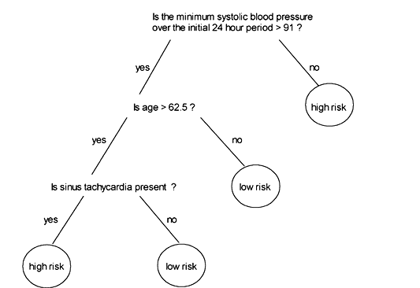

The general idea of the methods we are describing is to define an algorithm that uses data to create these tress. Regression and decision trees operate by predicting an outcome variable $Y$ by **partitioning** feature (predictor) space.

## Regression Trees

Let’s start with the case of a **continuous** outcome. The general idea here is to build a decision tree and at the end of each *node* we will have a different prediction $\hat{Y}$ for the outcome $Y$.

The **regression** tree model then:

1. Partitions space into $J$ non-overlapping regions, $R_1, R_2, \ldots, R_J$.
2. For every observation that falls within region $R_j$, predict the response as the mean of responses for training observations in $R_j$.

The important observation is that **Regression Trees create partitions recursively**.

For example, consider finding a good predictor $j$ to partition space along its axis. A recursive algorithm would look like this:

Find predictor $j$ and value $s$ that minimize RSS:

$$\sum_{i:\, x_i \in R_1(j,s))} (y_i - \hat{y}_{R_1})^2 +
\sum_{i:\, x_i \in R_2(j,s))} (y_i - \hat{y}_{R_2})^2$$

Where $R_1$ and $R_2$ are regions resulting from splitting observations on predictor $j$ and value $s$:

$$R_1(j,s) = \{X|X_j < s\} \text{ and } R_2(j,s) \{X|X_j \geq s\}$$

This is then applied recursively to regions $R_1$ and $R_2$. Within each region a prediction is made using $\hat{y}_{R_j}$ which is the mean of the response $Y$ of observations in $R_j$.

Let’s take a look at what this algorithm does on the `Boston Housing` data set. This dataset contains information collected by the U.S Census Service concerning housing in the area of Boston, MA in the 1970s. It was obtained from the [StatLib archive](http://lib.stat.cmu.edu/datasets/boston). It contains information including `medv` (median value of owner-occupied homes in $1000’s), `lstat` (% of individuals with lower socioeconomic status), `rm` (average number of rooms per dwelling), and `dis` (weighted distances to five Boston employment centres), among others with a total of 14 variables.

The dataset is small in size with only 506 cases, but we’ll use it for educational purposes.

We can use the `tree` package and use the `tree` function to fit the decision tree and plot the tree.

```r
library(tree)
library(MASS)
library(caret)

set.seed(1)

# Randomly sample 70% of the data for training
train_index <- createDataPartition(y = Boston$medv, p = 0.7, list = FALSE)

train_set <- Boston[train_index, ]
test_set  <- Boston[-train_index, ]

# Fit a regression tree using all of the available predictors
fit = tree(medv ~ ., data = train_set)

# Print a summary of the tree
summary(fit)
```

```
##
## Regression tree:
## tree(formula = medv ~ ., data = train_set)
## Variables actually used in tree construction:
## [1] "lstat" "rm"    "age"   "nox"   "crim"
## Number of terminal nodes:  9
## Residual mean deviance:  16.86 = 5852 / 347
## Distribution of residuals:
##     Min.  1st Qu.   Median     Mean  3rd Qu.     Max.
## -22.7300  -1.8500  -0.3119   0.0000   1.8500  28.8500
```

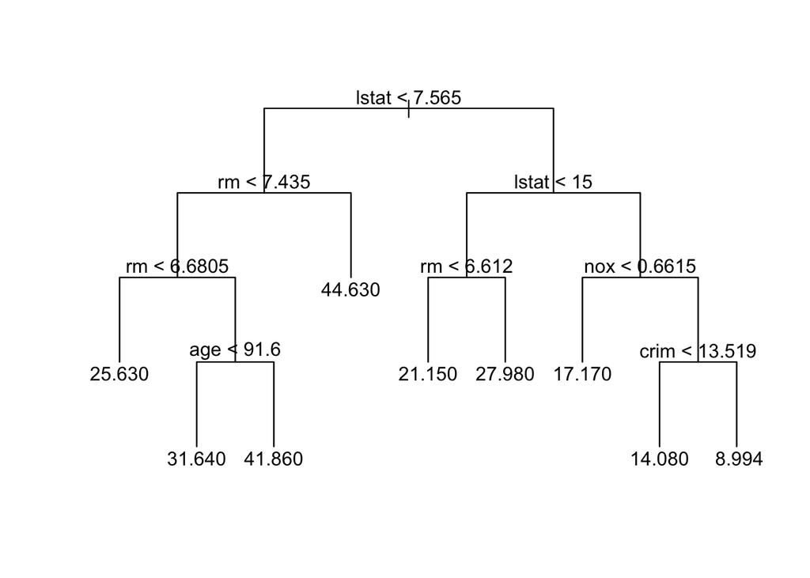

```r
plot(fit, type = "uniform")
text(fit, pretty = 0)
```

```r
# Use tree for prediction
preds <- predict(fit, newdata = test_set)
```

The tree suggests that houses with a higher number of rooms correspond to more expensive houses and predicts a median house price of $44,630 for a house with more than 7 rooms.

The idea behind the regression tree is that the outcome $Y$ is estimated (or predicted) to be it’s mean *within each of the data partitions*. Think of it as the conditional mean of $Y$ where conditioning is given by this region partitioning.

We can also use the predictions made to calculate MSE (mean square error) to compare models.

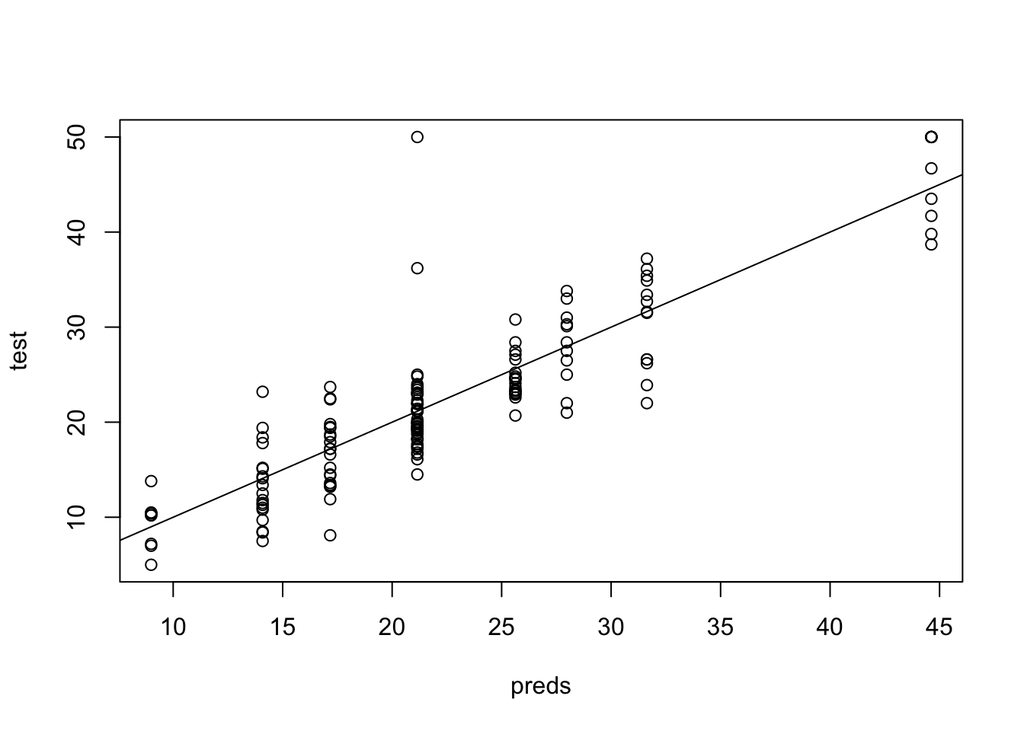

```r
test <- test_set$medv
plot(preds, test)
abline(0,1)
```

```r
mean((preds-test)^2)
```

```
## [1] 19.10161
```

```r
sqrt(mean((preds-test)^2))
```

```
## [1] 4.370539
```

The test set MSE associated with this tree is 19.1. The square root of the MSE is 4.37, indicating this model leads to test predictions that are within approximately $4,370 of the true median home value for the suburb.

The `rpart` package is an alternative method for fitting trees in R. It is much more feature rich, including performing cross-validation by default. It also has the ability to produce much nicer looking tree visualizations. Based on its default settings, it will often result in smaller trees than when using the `tree` package.

```r
library(rpart)
set.seed(1)

# Fit a regression tree using all of the available predictors
fit_rpart = rpart(medv ~ ., data = train_set)

# Print a summary of the tree
summary(fit_rpart)
```

```
## Call:
## rpart(formula = medv ~ ., data = train_set)
##   n= 356
##
##           CP nsplit rel error    xerror       xstd
## 1 0.46224493      0 1.0000000 1.0058246 0.10004122
## 2 0.13000875      1 0.5377551 0.6214606 0.06889048
## 3 0.10281834      2 0.4077463 0.4579724 0.05832243
## 4 0.03710371      3 0.3049280 0.3665824 0.05466323
## 5 0.02185604      4 0.2678243 0.3178023 0.05109253
## 6 0.01884224      5 0.2459682 0.3120840 0.05237063
## 7 0.01075097      6 0.2271260 0.2964878 0.05204276
## 8 0.01000000      7 0.2163750 0.2894516 0.05164846
##
## Variable importance
##   lstat      rm   indus     nox     age      zn    crim     dis ptratio     rad
##      30      21      11      11      10       8       4       3       1       1
##     tax
##       1
##
## Node number 1: 356 observations,    complexity param=0.4622449
##   mean=22.61713, MSE=81.94766
##   left son=2 (253 obs) right son=3 (103 obs)
##   Primary splits:
##       lstat   < 7.565    to the right, improve=0.4622449, (0 missing)
##       rm      < 6.797    to the left,  improve=0.4529412, (0 missing)
##       indus   < 7.225    to the right, improve=0.2734599, (0 missing)
##       ptratio < 19.65    to the right, improve=0.2239891, (0 missing)
##       nox     < 0.6695   to the right, improve=0.2175564, (0 missing)
##   Surrogate splits:
##       rm    < 6.5455   to the left,  agree=0.851, adj=0.485, (0 split)
##       zn    < 15.25    to the left,  agree=0.806, adj=0.330, (0 split)
##       indus < 5.04     to the right, agree=0.806, adj=0.330, (0 split)
##       age   < 38.95    to the right, agree=0.798, adj=0.301, (0 split)
##       nox   < 0.4475   to the right, agree=0.792, adj=0.282, (0 split)
##
## Node number 2: 253 observations,    complexity param=0.1028183
##   mean=18.69012, MSE=30.80026
##   left son=4 (113 obs) right son=5 (140 obs)
##   Primary splits:
```

[output cut: 92 more lines]

```
##
## Node number 11: 13 observations
##   mean=27.97692, MSE=30.06024
##
## Node number 12: 41 observations
##   mean=25.62927, MSE=22.44158
##
## Node number 13: 42 observations
##   mean=32.85238, MSE=28.85154
##
## Node number 16: 18 observations
##   mean=8.994444, MSE=5.149414
##
## Node number 17: 37 observations
##   mean=14.08378, MSE=4.891629
```

```r
# Use tree for prediction
preds <- predict(fit_rpart, newdata = test_set)
```

Let’s plot the resulting tree:

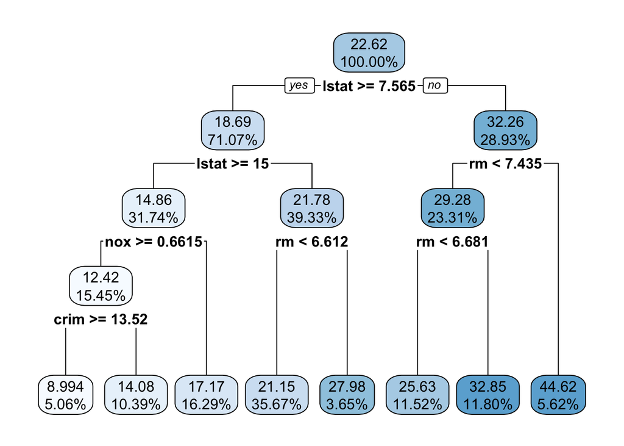

```r
rpart.plot(fit_rpart, digits = 4)
```

We get a similar but different tree than we did using the `tree` function. This tree has 8 terminal nodes (leaves) whereas the one before had 9 . We can also calculate the MSE and RMSE and compare the models:

```r
mean((preds-test)^2)
```

```
## [1] 19.44355
```

```r
sqrt(mean((preds-test)^2))
```

```
## [1] 4.409485
```

This model has slightly higher MSE and RMSE.

### Specifics of the regression tree algorithm

The recursive partitioning algorithm described above leads to a set of natural questions:

1. *When do we stop partitioning?*

We stop when adding a partition does not reduce MSE, or, when a partition has too few training observations. Even then, trees built with this stopping criterion tend to *overfit* to the training data. To avoid this, a post-processing step called **pruning** is used to make the tree smaller.

2. Why would a smaller tree tend to generalize better?

Pruning a decision tree simplifies the model, preventing it from overfitting the training data by removing branches that capture noise rather than genuine patterns. This simplification makes the model less complex, which improves its performance on new, unseen data.

When using the `tree` function from the `tree` package, the `cv.tree` function is used to determine a reasonable tree depth for the given dataset. For this dataset it seems that a depth of 8 works well since it reaches the minimum error or “deviance” with that number:

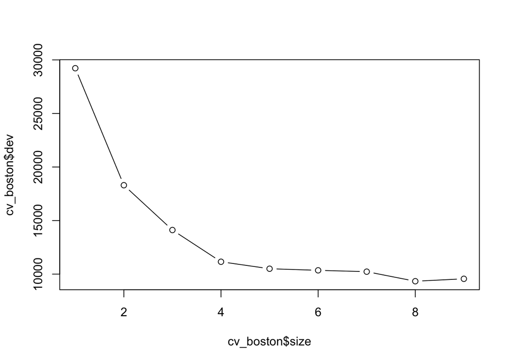

```r
set.seed(1)
cv_boston = cv.tree(fit)
plot(cv_boston$size, cv_boston$dev, type = 'b')
```

However, if we decide to prune a tree we can do so using the `prune.tree()` function:

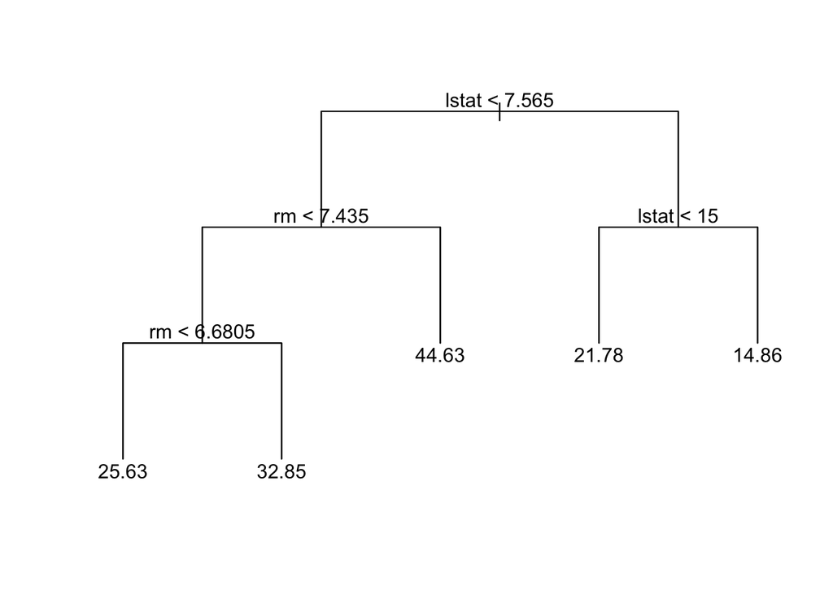

```r
prune_boston = prune.tree(fit, best = 5)
plot(prune_boston, type = "uniform")
text(prune_boston)
```

Let’s calculate the test set MSE for the pruned tree:

```r
preds_prune <- predict(prune_boston, newdata = test_set)
test = test_set$medv
mean((preds_prune-test)^2)
```

```
## [1] 24.85086
```

```r
sqrt(mean((preds_prune-test)^2))
```

```
## [1] 4.985063
```

The MSE of the pruned tree is greater than the original, so we should not prune this decision tree.

```r
set.seed(1)
fit_rpart = rpart(medv ~ ., data = train_set)
```

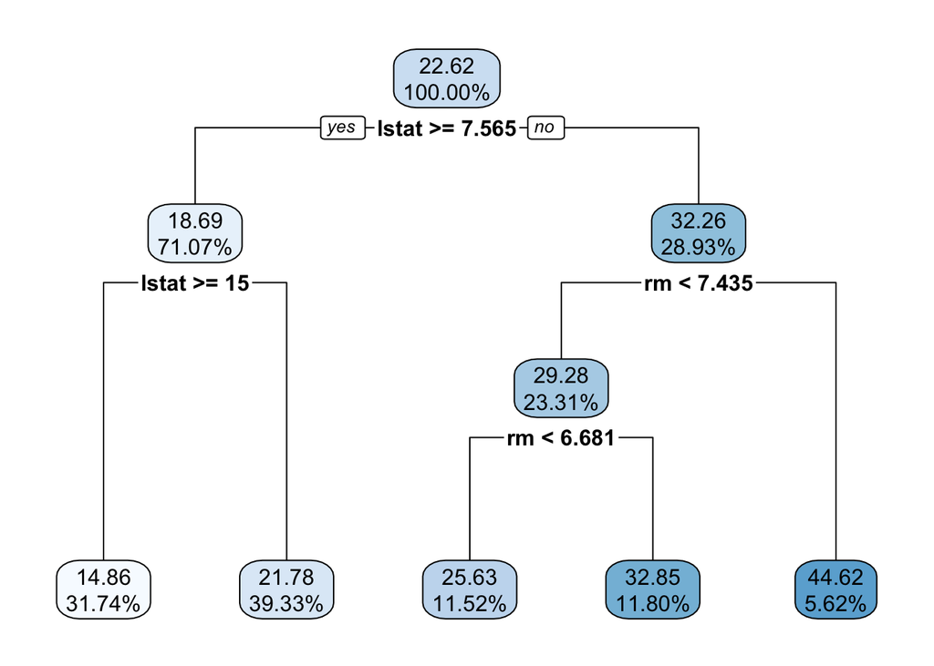

```r
p <- prune(fit_rpart, cp = 0.028)
rpart.plot(p, digits = 4)
```

```r
preds <- predict(p, newdata = test_set)
```

```r
mean((preds-test)^2)
```

```
## [1] 24.85086
```

```r
sqrt(mean((preds-test)^2))
```

```
## [1] 4.985063
```

Now the trees are identical and have the same MSE/RMSE.

## Random Forests

Random Forests are a **very popular** approach that address the shortcomings of decision trees via re-sampling of the training data. Their goal is to improve prediction performance and reduce instability by *averaging* multiple decision trees (a forest constructed with randomness). It has two features that help accomplish this.

The first trick is *Bagging* (bootstrap aggregation) General scheme:

1. Build many decision trees $T_1, T_2, \ldots, T_B$ from training set
2. Given a new observation, let each $T_j$ predict $\hat{y}_j$
3. For regression: predict average $\frac{1}{B} \sum_{j=1}^B \hat{y}_j$, for classification: predict with majority vote (most frequent class)

But how do we get many decision trees from a single training set?

For this we use the *bootstrap*. To create $T_j, \, j=1,\ldots,B$ from a training set of size $N$:

1. Create a bootstrap training set by sampling $N$ observations from training set **with replacement**
2. Build a decision tree from the bootstrap training set

Let’s look at this using the Boston housing dataset. We fit a Random Forest by using the `randomForest()` function. Here, `mtry = 13` indicates all 13 predictors should be considered for each split of the tree - in other words, **bagging** should be done.

```r
library(randomForest)
library(MASS)
fit_bag <- randomForest(medv ~ ., data = train_set, mtry = 13)
fit_bag
```

```
##
## Call:
##  randomForest(formula = medv ~ ., data = train_set, mtry = 13)
##                Type of random forest: regression
##                      Number of trees: 500
## No. of variables tried at each split: 13
##
##           Mean of squared residuals: 14.23466
##                     % Var explained: 82.63
```

How well does it perform on the test set?

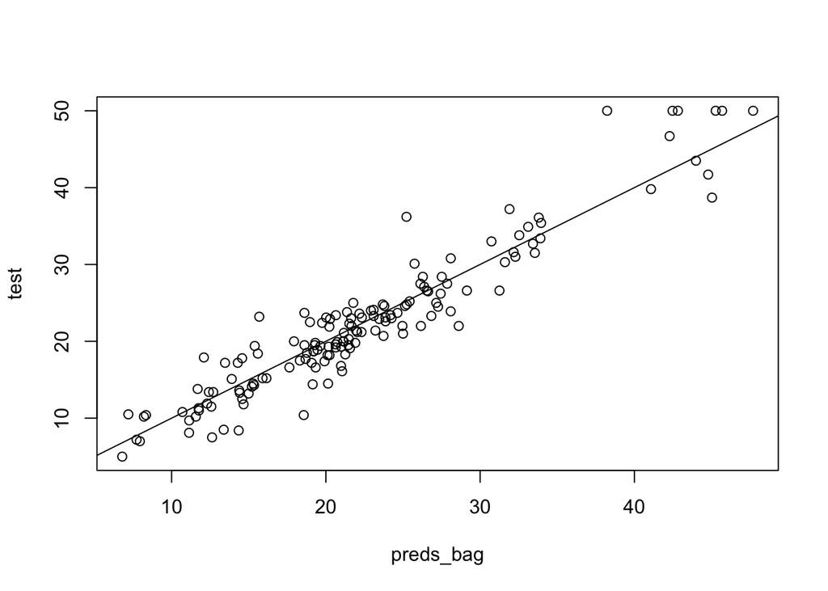

```r
preds_bag = predict(fit_bag, newdata = test_set)
plot(preds_bag, test)
abline(0,1)
```

```r
mean((preds_bag - test)^2)
```

```
## [1] 9.209669
```

```r
sqrt(mean((preds_bag - test)^2))
```

```
## [1] 3.034744
```

Much, much better than the one decision tree we used above. With Random Forest we get an MSE of 9.21 which (after square rooting) translates to our predictions being within $3,035 of the true median home value for the suburb.

This is much lower than the $4,370 we got when using the one decision tree.

The second Random Forest feature is to use a random selection of features to split when deciding partitions. Specifically, when building each tree $T_j$, at each recursive partition only consider a *randomly selected subset of predictors* to check for the best split. This **reduces correlation** between trees in a forest, improving prediction accuracy.

We can train a random forest as we did before, except now we use a smaller value for `mtry`. The default for regression trees is $p/3$ ($p$ is the number of predictors) and the default for classification trees is $\sqrt p$. The defaults come from the [original paper](https://www.stat.berkeley.edu/~breiman/randomforest2001.pdf) and a [follow-up paper](https://www.stat.berkeley.edu/~breiman/Using_random_forests_V3.1.pdf) that introduced the Random Forest model and have some mathematical reasons on why they are suggested.

The $\sqrt 13$ is small - 3.6 - so let’s try `mtry = 6` to see if we can get better performance.

```r
fit_rf <- randomForest(medv ~ ., data = train_set, mtry = 6)
preds_rf = predict(fit_rf, newdata = test_set)
mean((preds_rf - test)^2)
```

```
## [1] 10.00925
```

```r
sqrt(mean((preds_rf - test)^2))
```

```
## [1] 3.16374
```

Looks like the MSE for this random forest is worse (higher) with fewer predictors and the one using all of the predictors performs better.

Rather than changing `mtry` a bunch of times and comparing the performance of each model, we can use cross-validation to help find the best performing value. The setup is similar to what we saw with logistic regression, Naive Bayes, and KNN.

```r
# Define the tuning grid for mtry (numbers 2-13)
tune_grid <- expand.grid(mtry = seq(2, 13))

# Set up training control (e.g., repeated cross-validation)
train_control <- trainControl(method = "cv",
                              number = 10)

# Train the random forest model with tuning
rf_tuned_model <- train(medv ~ .,
                        data = train_set,
                        method = "rf",
                        tuneGrid = tune_grid,
                        trControl = train_control)

# View the results and optimal mtry
print(rf_tuned_model)
```

```
## Random Forest
##
## 356 samples
##  13 predictor
##
## No pre-processing
## Resampling: Cross-Validated (10 fold)
## Summary of sample sizes: 320, 321, 321, 320, 320, 321, ...
## Resampling results across tuning parameters:
##
##   mtry  RMSE      Rsquared   MAE
##    2    3.820984  0.8346431  2.519514
##    3    3.618008  0.8447581  2.388614
##    4    3.545530  0.8455778  2.353909
##    5    3.508104  0.8463937  2.326586
##    6    3.501270  0.8456823  2.325723
##    7    3.517672  0.8423850  2.332987
##    8    3.539399  0.8405534  2.355711
##    9    3.573090  0.8372022  2.355729
##   10    3.607730  0.8341349  2.367331
##   11    3.640190  0.8294652  2.387899
##   12    3.716452  0.8239906  2.400136
##   13    3.690969  0.8263174  2.405034
##
## RMSE was used to select the optimal model using the smallest value.
## The final value used for the model was mtry = 6.
```

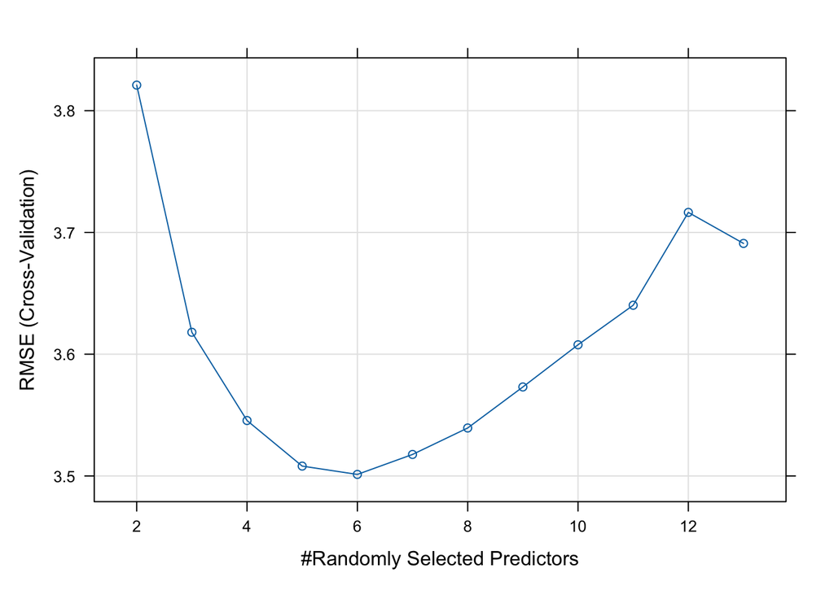

```r
plot(rf_tuned_model)
```

Interestingly, the best value using the training data is `mtry = 6` as we just ran before trying to tune the `mtry` parameter. However, just because the best performing parameter value is chosen using cross-validation, does not mean it will necessarily lead to the best performance on the test set.

One final neat thing about Random Forests - variable importance. A disadvantage of random forests is that we lose interpretability. However, we can use the fact that a bootstrap sample was used to construct trees to measure **variable importance** from the random forest. The importance of a variable translates to how predictive that variable is.

Here is a table of **variable importance** values for the random forest we just constructed with `mtry = 6`.

```r
library(knitr)
variable_importance <- importance(fit_rf)
tmp <- tibble(feature = rownames(variable_importance),
                  Gini = variable_importance[,1]) %>%
                  arrange(desc(Gini))
kable(tmp[1:10,])
```

| feature | Gini |
| --- | --- |
| lstat | 10163.4095 |
| rm | 9364.2909 |
| nox | 1667.2821 |
| dis | 1604.2735 |
| crim | 1464.4502 |
| indus | 1429.4463 |
| ptratio | 1003.1227 |
| age | 672.2566 |
| tax | 557.5735 |
| black | 446.2853 |

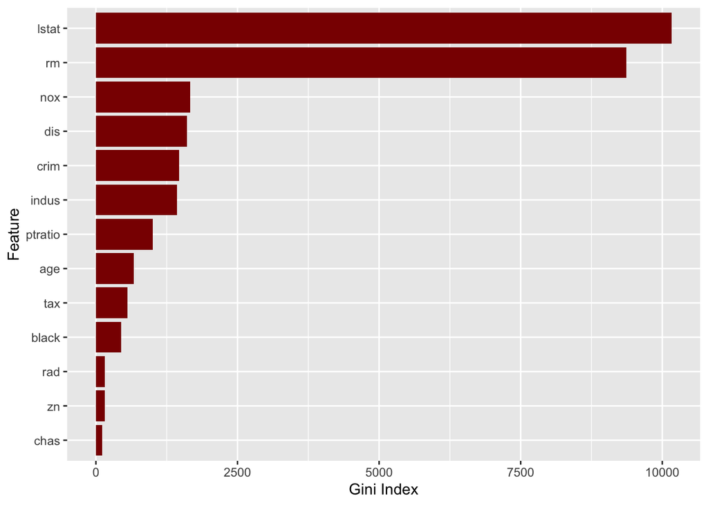

```r
tmp %>% ggplot(aes(x = reorder(feature, Gini), y = Gini)) +
        geom_bar(stat = 'identity', fill = "darkred") +
        coord_flip() +
        xlab("Feature") +
        ylab("Gini Index")
```

In this case, `lstat` (metric for low socio-economic status) and `rm` (average number of rooms) are the most predictive features.

## Classification Trees

We previously used decision trees and Random Forests for regression because our outcome variable was continuous. We now turn to classification trees, which are appropriate when the outcome is categorical. Although we have used the melanoma dataset throughout earlier lectures, it does not work well with tree-based classification methods; the available predictors do not provide enough information to meaningfully split the data, resulting in trees that contain only a single split. To better illustrate how classification trees work, we will instead use the `PimaIndiansDiabetes2` dataset from the `mlbench` package (the same dataset you saw in homework 4).

Note that we are using `PimaIndiansDiabetes2` and not `PimaIndiansDiabetes`. The dataset `PimaIndiansDiabetes2` contains a corrected version of the original data set. While the UCI repository index claims that there are no missing values, closer inspection of the data shows several physical impossibilities, e.g., blood pressure or body mass index of 0. In `PimaIndiansDiabetes2`, all zero values of `glucose`, `pressure`, `triceps`, `insulin` and `mass` have been set to `NA`.

- `pregnant`: Number of times pregnant
- `glucose`: Plasma glucose concentration (glucose tolerance test)
- `pressure`: Diastolic blood pressure (mm Hg)
- `triceps`: Triceps skin fold thickness (mm)
- `insulin`: 2-Hour serum insulin (mu U/ml)
- `mass`: Body mass index (BMI)
- `pedigree`: Diabetes pedigree function (a genetic risk score)
- `age`: Age (years)
- `diabetes`: Class variable (test for diabetes)

```r
library(mlbench)
data("PimaIndiansDiabetes2")

PimaIndiansDiabetes2 <- PimaIndiansDiabetes2

head(PimaIndiansDiabetes2)
```

```
##   pregnant glucose pressure triceps insulin mass pedigree age diabetes
## 1        6     148       72      35      NA 33.6    0.627  50      pos
## 2        1      85       66      29      NA 26.6    0.351  31      neg
## 3        8     183       64      NA      NA 23.3    0.672  32      pos
## 4        1      89       66      23      94 28.1    0.167  21      neg
## 5        0     137       40      35     168 43.1    2.288  33      pos
## 6        5     116       74      NA      NA 25.6    0.201  30      neg
```

```r
colSums(is.na(PimaIndiansDiabetes2))
```

```
## pregnant  glucose pressure  triceps  insulin     mass pedigree      age
##        0        5       35      227      374       11        0        0
## diabetes
##        0
```

Let’s split the data into training and test sets. We have class imbalance so we will use the `stratified` function.

```r
library(splitstackshape)
set.seed(1)

x            <- stratified(PimaIndiansDiabetes2, "diabetes", 0.7, keep.rownames = TRUE)
train_set    <- x %>% dplyr::select(-rn)
train_index  <- as.numeric(x$rn)
test_set     <- PimaIndiansDiabetes2[-train_index,]
test_set_y   <- test_set$diabetes
dim(train_set)
```

```
## [1] 538   9
```

```r
dim(test_set)
```

```
## [1] 230   9
```

Because the dataset includes genuine missing values, we must deal with them before fitting any machine learning models. Many models, including decision trees and random forests in caret, do not accept missing values directly and will fail unless the missing entries are imputed.

Imputation replaces missing values with estimated values based on the observed data. Although imputation is necessary, it must be performed carefully to avoid data leakage. Data leakage occurs when information from the test set influences any part of the model-building (training) process. If the imputation model uses information from the test set—for example, if we compute medians or regression imputation using both training and test data—then the model indirectly “sees” the test set during training. This can lead to overly optimistic performance estimates that will not generalize to new, unseen data.

To avoid leakage, we follow a strict rule: any data-dependent preprocessing step must be learned using only the training set. This includes imputation. We first fit an imputation model using only the predictors in the training data. Once this imputation model is created, we apply the same imputation model to both the training and the test set predictors. In this way, the test set is transformed using rules learned exclusively from the training data, which mirrors the real-world scenario in which a model encounters new data after it has already been trained. By separating the imputation model fitting from the application of that model, we ensure that the preprocessing pipeline is consistent between training and testing and that no information from the test set influences model development.

Below is the implementation of this approach using the `preProcess` function from the `caret` package.

```r
# Separate predictors from outcome for imputation
train_x <- train_set %>% dplyr::select(-diabetes)
train_y <- train_set$diabetes

test_x <- test_set %>% dplyr::select(-diabetes)
test_y <- test_set$diabetes

# Fit imputation model on training data predictors only
imputation_model <- preProcess(train_x, method = "medianImpute")

# Apply same imputation model on the training and test sets
train_x_imp <- predict(imputation_model, train_x)
test_x_imp  <- predict(imputation_model, test_x)

# Re-combine with outcome
pima_imputed_train <- train_x_imp %>%
  mutate(diabetes = train_y)

pima_imputed_test <- test_x_imp %>%
  mutate(diabetes = test_y,
         diabetes_num = as.factor(ifelse(diabetes == "neg", 0, 1)))
```

Once the data have been imputed and prepared, we can begin fitting predictive models. We first train a Random Forest classifier. The `caret` framework allows us to tune the value of `mtry`, the number of predictors considered at each split, through cross-validation. We specify a grid of candidate `mtry` values and let `caret` fit multiple models. The model that performs best, as measured by the area under the ROC curve, is selected as the final Random Forest model. This helps ensure that the model generalizes well beyond the training data.

```r
set.seed(1)
tune_grid <- expand.grid(mtry = seq(2, 8))

train_control <- trainControl(method = "cv",
                              number = 10,
                              classProbs = TRUE,
                              summaryFunction = twoClassSummary)

rf_tuned_model <- train(diabetes ~ .,
                        data      = pima_imputed_train,
                        method    = "rf",
                        tuneGrid  = tune_grid,
                        trControl = train_control,
                        metric    = "ROC")

rf_tuned_model
```

```
## Random Forest
##
## 538 samples
##   8 predictor
##   2 classes: 'neg', 'pos'
##
## No pre-processing
## Resampling: Cross-Validated (10 fold)
## Summary of sample sizes: 484, 485, 484, 485, 484, 484, ...
## Resampling results across tuning parameters:
##
##   mtry  ROC        Sens       Spec
##   2     0.8612907  0.8800000  0.6494152
##   3     0.8606182  0.8685714  0.6652047
##   4     0.8619298  0.8628571  0.6757310
##   5     0.8630535  0.8600000  0.6809942
##   6     0.8589348  0.8485714  0.6707602
##   7     0.8572139  0.8428571  0.6760234
##   8     0.8575940  0.8457143  0.6543860
##
## ROC was used to select the optimal model using the largest value.
## The final value used for the model was mtry = 5.
```

After training, we use the fitted model to predict diabetes probabilities for the test set. These predicted probabilities reflect the model’s belief about the likelihood of diabetes for each individual given their predictor values. Converting these probabilities into class predictions using a 0.5 threshold allows us to evaluate the model’s classification accuracy. The confusion matrix summarizes the model’s performance by providing true positives, false positives, true negatives, and false negatives. This framework allows us to assess how well the Random Forest distinguishes between individuals with and without diabetes.

```r
p_hat_rf = predict(rf_tuned_model, newdata = pima_imputed_test, type = "prob")[,2]
y_hat_rf = factor(ifelse(p_hat_rf > 0.5, 1, 0))

confusionMatrix(data = as.factor(y_hat_rf),
                reference = pima_imputed_test$diabetes_num,
                positive = "1")
```

```
## Confusion Matrix and Statistics
##
##           Reference
## Prediction   0   1
##          0 117  32
##          1  33  48
##
##                Accuracy : 0.7174
##                  95% CI : (0.6545, 0.7746)
##     No Information Rate : 0.6522
##     P-Value [Acc > NIR] : 0.02107
##
##                   Kappa : 0.3789
##
##  Mcnemar's Test P-Value : 1.00000
##
##             Sensitivity : 0.6000
##             Specificity : 0.7800
##          Pos Pred Value : 0.5926
##          Neg Pred Value : 0.7852
##              Prevalence : 0.3478
##          Detection Rate : 0.2087
##    Detection Prevalence : 0.3522
##       Balanced Accuracy : 0.6900
##
##        'Positive' Class : 1
##
```

For the purposes of model comparison, we next fit a decision tree model. Using `caret`, we tune the tree’s complexity parameter, `cp`, which controls how much the model is allowed to grow. A very small `cp` allows the tree to grow deep and potentially overfit the training data, while a larger `cp` prunes the tree back to a simpler structure. By selecting the `cp` value that maximizes the cross-validated ROC, we identify a balance between model complexity and predictive performance.

After training the model, we again evaluate its predictions on the test set. The resulting confusion matrix summarizes how well the tree performs compared to the Random Forest model. To better understand the fitted tree, we visualize it using `rpart.plot`. The plot displays the splitting variable and threshold at each node, as well as the predicted class and class probabilities at each terminal leaf. This visualization provides insight into which variables the model considers most important and how it separates individuals into predicted diabetes and non-diabetes categories. The table of decision rules further translates the tree structure into a readable set of “if–then” statements that highlight the decision-making logic of the tree.

```r
set.seed(1)

# Fit a classification tree using all of the available predictors
rpart_tuned_model <- train(diabetes ~ .,
                           data      = pima_imputed_train,
                           method    = "rpart",
                           trControl = train_control,
                           tuneLength = 10, # caret will try different complexity parameters
                           metric    = "ROC")

rpart_tuned_model
```

```
## CART
##
## 538 samples
##   8 predictor
##   2 classes: 'neg', 'pos'
##
## No pre-processing
## Resampling: Cross-Validated (10 fold)
## Summary of sample sizes: 484, 485, 484, 485, 484, 484, ...
## Resampling results across tuning parameters:
##
##   cp          ROC        Sens       Spec
##   0.00000000  0.7787636  0.8371429  0.6119883
##   0.03546099  0.7424896  0.8657143  0.5210526
##   0.07092199  0.6698663  0.9514286  0.3883041
##   0.10638298  0.6698663  0.9514286  0.3883041
##   0.14184397  0.6698663  0.9514286  0.3883041
##   0.17730496  0.6698663  0.9514286  0.3883041
##   0.21276596  0.6698663  0.9514286  0.3883041
##   0.24822695  0.6698663  0.9514286  0.3883041
##   0.28368794  0.6698663  0.9514286  0.3883041
##   0.31914894  0.5599708  0.9600000  0.1599415
##
## ROC was used to select the optimal model using the largest value.
## The final value used for the model was cp = 0.
```

```r
# Use tree for prediction
p_hat_rpart= predict(rpart_tuned_model, newdata = pima_imputed_test, type = "prob")[,2]
y_hat_rpart = factor(ifelse(p_hat_rpart > 0.5, 1, 0))

# Output performance metrics
confusionMatrix(data = as.factor(y_hat_rpart),
                reference = pima_imputed_test$diabetes_num,
                positive = "1")
```

```
## Confusion Matrix and Statistics
##
##           Reference
## Prediction   0   1
##          0 120  38
##          1  30  42
##
##                Accuracy : 0.7043
##                  95% CI : (0.6408, 0.7625)
##     No Information Rate : 0.6522
##     P-Value [Acc > NIR] : 0.05433
##
##                   Kappa : 0.3328
##
##  Mcnemar's Test P-Value : 0.39595
##
##             Sensitivity : 0.5250
##             Specificity : 0.8000
##          Pos Pred Value : 0.5833
##          Neg Pred Value : 0.7595
##              Prevalence : 0.3478
##          Detection Rate : 0.1826
##    Detection Prevalence : 0.3130
##       Balanced Accuracy : 0.6625
##
##        'Positive' Class : 1
##
```

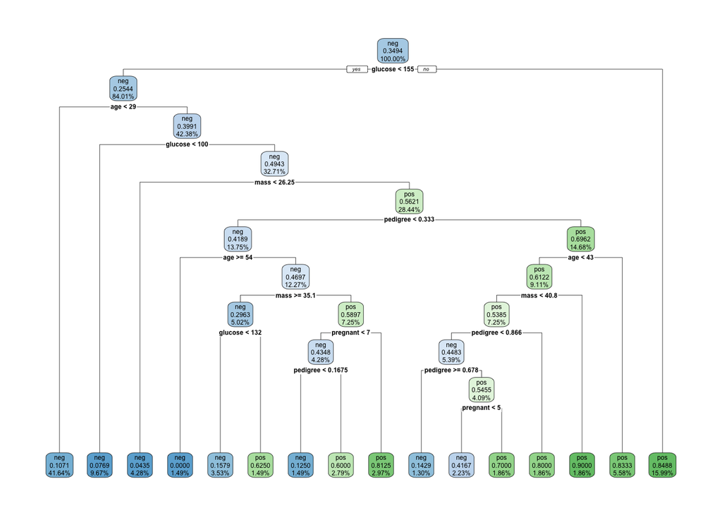

```r
# Access the final tree
final_tree <- rpart_tuned_model$finalModel

# Plot the tree
rpart.plot(final_tree, digits = 4)
```

```r
# Create a table of final decision rules for the tree
kable(rpart.rules(final_tree))
```

|  | .outcome |  |  |  |  |  |  |  |  |  |  |  |  |  |  |  |  |  |  |  |  |  |  |  |  |  |  |  |  |
| --- | --- | --- | --- | --- | --- | --- | --- | --- | --- | --- | --- | --- | --- | --- | --- | --- | --- | --- | --- | --- | --- | --- | --- | --- | --- | --- | --- | --- | --- |
| 92 | 0.00 | when | glucose | is | 100 | to | 155 | & | age | >= |  |  | 54 | & | mass | >= |  |  | 26 | & | pedigree | < | 0.33 |  |  |  |  |  |  |
| 22 | 0.04 | when | glucose | is | 100 | to | 155 | & | age | >= |  |  | 29 | & | mass | < | 26 |  |  |  |  |  |  |  |  |  |  |  |  |
| 10 | 0.08 | when | glucose | < | 100 |  |  | & | age | >= |  |  | 29 |  |  |  |  |  |  |  |  |  |  |  |  |  |  |  |  |
| 4 | 0.11 | when | glucose | < | 155 |  |  | & | age | < | 29 |  |  |  |  |  |  |  |  |  |  |  |  |  |  |  |  |  |  |
| 748 | 0.12 | when | glucose | is | 100 | to | 155 | & | age | is | 29 | to | 54 | & | mass | is | 26 | to | 35 | & | pedigree | < | 0.17 |  |  | & | pregnant | < | 7 |
| 752 | 0.14 | when | glucose | is | 100 | to | 155 | & | age | is | 29 | to | 43 | & | mass | is | 26 | to | 41 | & | pedigree | is | 0.68 | to | 0.87 |  |  |  |  |
| 372 | 0.16 | when | glucose | is | 100 | to | 132 | & | age | is | 29 | to | 54 | & | mass | >= |  |  | 35 | & | pedigree | < | 0.33 |  |  |  |  |  |  |
| 1506 | 0.42 | when | glucose | is | 100 | to | 155 | & | age | is | 29 | to | 43 | & | mass | is | 26 | to | 41 | & | pedigree | is | 0.33 | to | 0.68 | & | pregnant | < | 5 |
| 749 | 0.60 | when | glucose | is | 100 | to | 155 | & | age | is | 29 | to | 54 | & | mass | is | 26 | to | 35 | & | pedigree | is | 0.17 | to | 0.33 | & | pregnant | < | 7 |
| 373 | 0.62 | when | glucose | is | 132 | to | 155 | & | age | is | 29 | to | 54 | & | mass | >= |  |  | 35 | & | pedigree | < | 0.33 |  |  |  |  |  |  |
| 1507 | 0.70 | when | glucose | is | 100 | to | 155 | & | age | is | 29 | to | 43 | & | mass | is | 26 | to | 41 | & | pedigree | is | 0.33 | to | 0.68 | & | pregnant | >= | 5 |
| 377 | 0.80 | when | glucose | is | 100 | to | 155 | & | age | is | 29 | to | 43 | & | mass | is | 26 | to | 41 | & | pedigree | >= |  |  | 0.87 |  |  |  |  |
| 375 | 0.81 | when | glucose | is | 100 | to | 155 | & | age | is | 29 | to | 54 | & | mass | is | 26 | to | 35 | & | pedigree | < | 0.33 |  |  | & | pregnant | >= | 7 |
| 95 | 0.83 | when | glucose | is | 100 | to | 155 | & | age | >= |  |  | 43 | & | mass | >= |  |  | 26 | & | pedigree | >= |  |  | 0.33 |  |  |  |  |
| 3 | 0.85 | when | glucose | >= |  |  | 155 |  |  |  |  |  |  |  |  |  |  |  |  |  |  |  |  |  |  |  |  |  |  |
| 189 | 0.90 | when | glucose | is | 100 | to | 155 | & | age | is | 29 | to | 43 | & | mass | >= |  |  | 41 | & | pedigree | >= |  |  | 0.33 |  |  |  |  |

Although accuracy and confusion matrices are useful, they can be misleading when class imbalance is present or when the cost of misclassification differs between classes. ROC curves provide a threshold-independent view of model performance by plotting sensitivity against 1-specificity across all possible probability cutoffs. A model with strong discriminatory ability will have a curve that bows toward the upper left corner, indicating high sensitivity and specificity across a wide range of thresholds.

To compare the Random Forest and decision tree models, we compute ROC curves for each and visualize them on the same plot. This makes it easy to see which model achieves a higher area under the curve (AUC), which is a common measure of overall classification performance. In most cases, the Random Forest model performs better because its ensemble structure reduces variance and captures more complex patterns in the data. The decision tree may be easier to interpret, but it often sacrifices predictive accuracy for simplicity. The AUC values printed below the plot concretely quantify these differences.

```r
library(pROC)

roc_tree  <- roc(pima_imputed_test$diabetes_num, p_hat_rpart)
roc_rf    <- roc(pima_imputed_test$diabetes_num, p_hat_rf)
```

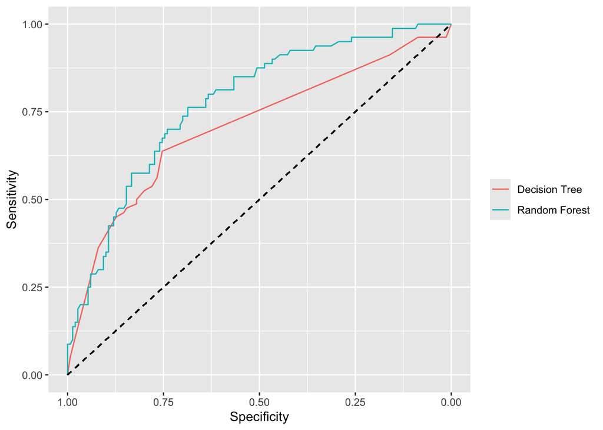

```r
ggroc(list("Decision Tree" = roc_tree,
           "Random Forest" = roc_rf)) +
  theme(legend.title = element_blank()) +
  geom_segment(aes(x = 1, xend = 0, y = 0, yend = 1),
               color = "black",
               linetype = "dashed") +
  ylab("Sensitivity") +
  xlab("Specificity")
```

```r
auc(roc_tree)
```

```
## Area under the curve: 0.7078
```

```r
auc(roc_rf)
```

```
## Area under the curve: 0.7763
```

## Tree-based methods summary

Tree-based methods offer a flexible and intuitive approach to prediction problems. Decision trees provide a clear, interpretable model that can reveal important structure in the data, such as nonlinear relationships and high-order interactions between predictors. However, because a single tree is highly sensitive to small changes in the data, it often lacks predictive accuracy compared to more robust ensemble methods. Random Forests address this limitation by averaging over many trees built on bootstrap samples, which substantially reduces variance and improves predictive performance. Although Random Forests are less interpretable than decision trees, they typically achieve strong results across a wide range of real-world classification problems. Understanding the trade-off between interpretability and predictive power is an important part of choosing an appropriate model for a given application.